# HW1

Gharehmohammadzadehghashghaei, Miciakova, Zohoorianmoftakharkhodaparast

2025-02-18

### Part 1

**Problem Statement**  
We have a binary response $Y \in \{0,1\}$ and a single predictor $X \in \mathbb{R}$. The conditional distributions and priors are:

- $X \mid Y=0 \sim \text{Unif}(-3,1)$
- $X \mid Y=1 \sim \text{Unif}(-1,3)$
- $\Pr(Y=0) = \Pr(Y=1) = \tfrac{1}{2}$

We want to find the **Bayes classification rule** $\eta^*(x)$, i.e., the rule that minimizes the misclassification probability under the 0/1 loss.

#### 1. Bayes classification rule $\eta^*(x)$

$(Y, X)$ are random variables with $Y \in \{0,1\}$ and $X \in \mathbb{R}$. Suppose that

$$(X \mid Y = 0) \sim \text{Unif}(-3,1) \quad \text{and} \quad (X \mid Y =
1) \sim \text{Unif}(-1,3)$$

Further suppose that $\mathbb{P}(Y = 0) = \mathbb{P}(Y = 1) = \frac{1}{2}$.

The regression function is defined as follows:

$$r(x) = \mathbb{E}(Y \mid X = x) = \mathbb{P}(Y = 1 \mid X = x) =
\frac{\pi_1 f_1(x)}{\pi_1 f_1(x) + (1 - \pi_1) f_0(x)}$$

where $\pi_1 = \mathbb{P}(Y = 1)$, $f_1(x) = f(x \mid Y = 1)$ and $f_0(x) = f(x \mid Y = 0)$.

The Bayes classification rule $\eta^*(x)$ is defined as:

$$\eta^*(x) =
\begin{cases}
1 & \text{if } \mathbb{P}(Y = 1 \mid X = x) > \mathbb{P}(Y = 0
\mid X = x) \\
0 & \text{otherwise}
\end{cases}$$

$$= \begin{cases}
1 & \text{if } \pi_1 f_1(x) > (1 - \pi_1) f_0(x) \\
0 & \text{otherwise}
\end{cases}$$

Since we have $\pi_1 = \pi_0 = \frac{1}{2}$:

$$\eta^*(x) =
\begin{cases}
1 & \text{if } f_1(x) > f_0(x) \\
0 & \text{otherwise}
\end{cases}$$

$$f_1(x) =
\begin{cases}
\frac{1}{4} & \text{if } -1 \leq x \leq 3 \\
0 & \text{otherwise}
\end{cases}$$

and

$$f_0(x) =
\begin{cases}
\frac{1}{4} & \text{if } -3 \leq x \leq 1 \\
0 & \text{otherwise}
\end{cases}$$

- $x < -3$:

  $$f_1(x) = 0, \quad f_0(x) = 0 \Rightarrow f_1(x) \not> f_0(x)
  \Rightarrow \eta^*(x) = 0$$
- $-3 \leq x < -1$:

  $$f_1(x) = 0, \quad f_0(x) = \frac{1}{4} \Rightarrow f_1(x) \not>
  f_0(x) \Rightarrow \eta^*(x) = 0$$
- $-1 \leq x \leq 1$:

  $$f_1(x) = \frac{1}{4}, \quad f_0(x) = \frac{1}{4} \Rightarrow f_1(x)
  \not> f_0(x) \Rightarrow \eta^*(x) = 0$$
- $1 < x \leq 3$:

  $$f_1(x) = \frac{1}{4}, \quad f_0(x) = 0 \Rightarrow f_1(x) > f_0(x)
  \Rightarrow \eta^*(x) = 1$$
- $x > 3$:

  $$f_1(x) = 0, \quad f_0(x) = 0 \Rightarrow f_1(x) \not> f_0(x)
  \Rightarrow \eta^*(x) = 0$$

### Final Bayes Classification Rule:

$$\eta^*(x) =
\begin{cases}
1 & \text{if } 1 < x \leq 3 \\
0 & \text{otherwise}
\end{cases}$$

**Problem Statement**  
2. Simulate $n = 1000$ data from the joint data model $p(y, x) = p(x \mid y) \cdot p(y)$ described above, and then:

- Plot the data (or a subset for clarity) together with the regression function $r(x)$ that defines $\eta^{\star}(x)$.
- Evaluate the performance of the Bayes Classifiers $\eta^{\star}(x)$ on this simple (only 1 feature!) data.
- Apply any other practical classifier of your choice to these data and comparatively comment on its performance (with respect to those of the Bayes classifiers). Of course, those $n$ training data should be used for training and validation too (in case there are tuning parameters).
- We choose $n = 1000$ as our sample size.
- The variable $\mathbf{Y}$ is generated from a Bernoulli distribution with probability 0.5, meaning $\mathbf{Y}$ takes the value 0 or 1 with equal likelihood.
- We create a numeric vector **x** to store our predictor variable.
- For each observation *i*:
  - If $Y[i] = 0$, then $X[i]$ is drawn from a **Uniform**$(-3,1)$ distribution.
  - If $Y[i] = 1$, then $X[i]$ is drawn from a **Uniform**$(-1,3)$ distribution.
- This reflects the joint model $p(x,y) = p(y) p(x \mid y)$ where:
  - $p(y) = 0.5$
  - $p(x \mid y = 0) \sim \text{Uniform}(-3,1)$
  - $p(x \mid y = 1) \sim \text{Uniform}(-1,3)$

and then we show the results:

```
##  [1]  2.39317289 -0.74901467  0.27938035  1.15744118  0.99608040 -0.91109072
##  [7]  1.21637254 -0.12040959 -0.05713908  2.24751872
```

#### 1. Choosing the Sample Size

- You selected a sample size of $n = 1000$.
- This means that you will generate a dataset containing 1000 observations.

#### 2. Generating the Variable $\mathbf{Y}$

- You defined a random variable $\mathbf{Y}$ that follows a **Bernoulli distribution**.
- A Bernoulli distribution is a discrete probability distribution where a random variable takes only two possible values: **0** or **1**.

#### 3. Setting the Probability Parameter

- You set the probability parameter of the Bernoulli distribution to **0.5**.
- This means that each observation of $\mathbf{Y}$ has an equal likelihood of being **0** or **1**.
- In other words:
  - $P(Y = 1) = 0.5$
  - $P(Y = 0) = 0.5$

#### Conclusion

- Since the probability is **0.5**, the generated data will be evenly split between **0s** and **1s** on average.

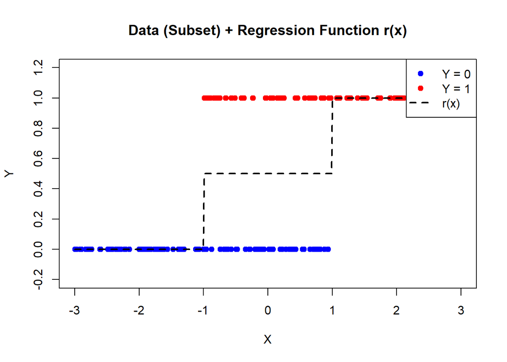

### Plot Summary

#### Stepwise Regression Function $r(x)$

- The black dashed line suggests a **stepwise function**, indicating that the probability of $Y = 1$ changes abruptly at certain values of $X$.
- This implies a **piecewise constant estimation** of $P(Y = 1 | X)$, which is common in **non-parametric methods like decision trees**.

#### Classification Decision

- For **low values of $X$** (e.g., $X < -1$), most of the points are **blue (Y = 0)**, meaning the probability of $Y = 1$ is low.
- As $X$ increases (e.g., around $X = -1$), the probability shifts, and more **red points (Y = 1)** appear, indicating a higher probability of $Y = 1$.
- The stepwise function adjusts its prediction based on **changes in the observed data distribution**.
- The regression function $r(x)$ suggests that the relationship between $X$ and $Y$ is highly **non-linear**.
- Instead of a smooth probability curve (like logistic regression), a **stepwise approach** is used to estimate $P(Y = 1 | X)$.
- This method is common in **classification trees, histogram-based estimators, or non-parametric regression models**.

#### 1. Definition of `bayes_classifier`

- This function takes a single numeric input `x`.
- It applies a simple decision rule:
  - If $x < 0$, predict the class as `0`.
  - Otherwise (i.e., $x \ge 0$), predict the class as `1`.
- In many examples, this threshold at $x = 0$ is considered the “Bayes” decision boundary if the data suggests that’s the optimal split for minimizing misclassification.

#### 2. Applying the Classifier to the Dataset

- Here, `x` is a vector of feature values.
- `sapply(x, bayes_classifier)` applies the `bayes_classifier` function to each element of `x`.
- The result is a vector of predicted classes, stored in `y_pred_bayes`.

#### 3. Calculating the Misclassification Rate

- `y_pred_bayes != Y` creates a logical vector (TRUE if the prediction differs from the true label, FALSE otherwise).
- `mean(y_pred_bayes != Y)` computes the proportion of misclassified observations.
- `error_bayes` is the overall misclassification rate for this threshold-based classifier.
- Finally, the `cat` function prints the result.

#### Result:

- The misclassification rate is **23.9%**.
- This suggests that the decision rule $x < 0 \to 0$ and $x \ge 0 \to 1$ incorrectly classifies about **23.9%** of the observations.
- Despite being called the “Bayes classifier” in this context (often meaning the theoretically optimal rule under certain assumptions), the data may have enough overlap or noise such that nearly one in four observations are misclassified by this simple threshold rule.

```
## Bayes classifier misclassification rate: 0.239
```

#### Data Splitting (70% train, 30% test)

`train_idx = sample(seq_len(n), size = round(0.7 * n))` randomly selects 70% of the data indices (from 1 to n) to be in the training set.  
`X_train`, `Y_train` are the features and labels for the training set; `X_test`, `Y_test` are the remaining 30% for testing.

#### Logistic Regression Model

A data frame `df_train` is created with the training feature (`X_train`) and response (`Y_train`).  
`glm(Y ~ X, data = df_train, family = binomial)` fits a logistic regression model, where `Y` is the binary outcome and `X` is the predictor. The `family = binomial` option specifies a logistic link.

#### Predicting on the Test Set

A data frame `df_test` is created from the test features `X_test`.  
`predict(logreg, newdata = df_test, type = "response")` obtains the predicted probabilities $\hat{P}(Y=1 \mid X)$ from the logistic model.  
`Y_pred_test = (Y_prob_test >= 0.5)` converts probabilities to 0/1 classifications using the 0.5 threshold.  
`logreg_err = mean(Y_pred_test != Y_test)` computes the misclassification rate for the logistic regression on the test set.

#### Bayes Classifier Predictions

`Y_pred_bayes_test = sapply(X_test, bayes_rule)` applies a custom function `bayes_rule` to each value in `X_test`. This function encodes the theoretical Bayes rule (e.g., based on uniform distributions, we classify as 1 if $-1 \le x < 3$, and 0 otherwise).  
`bayes_err_test = mean(Y_pred_bayes_test != Y_test)` computes the misclassification rate for the Bayes classifier.

#### Comparing Results

The code prints out the misclassification rates for both models: - **Logistic Regression misclassification rate (test):** approximately `0.243333` (24.33%).  
- **Bayes classifier misclassification rate (test):** approximately `0.216667` (21.67%).

#### What do the results mean?

The Bayes classifier, derived from the true underlying distributions (Uniform(-3,1) vs. Uniform(-1,3)), represents the theoretical *optimal* decision rule under those assumptions.

The logistic regression model, while flexible, is still a **parametric** method that estimates probabilities from finite data. It may not perfectly capture the true boundary without sufficient data or correct model specification.

Consequently, we see that the Bayes classifier achieves a lower misclassification rate (around **21.7%**) compared to the logistic regression (around **24.3%**). This difference illustrates the advantage of knowing the true distributional assumptions in advance (Bayes rule) versus estimating the model from data (logistic regression).

```
## Logistic Regression misclassification rate (test): 0.2433333
```

```
## Bayes classifier misclassification rate (test): 0.2166667
```

**Problem Statement**

Since you are simulating the data, you can actually see what happens in repeated sampling. Hence, repeat the sampling M = 10000 times keeping n = 1000 fixed (a simple for-loop will do it), and redo the comparison. Who’s the best now? Comment.

#### Initializing the Simulation**

- `set.seed(123)`: Ensures that the results are reproducible by setting a fixed seed for the random number generator.
- `M <- 1000`: Specifies the number of Monte Carlo replications (i.e., the experiment is repeated 1000 times).
- `n <- 1000`: Defines the sample size for each replication (i.e., each dataset contains 1000 observations).

#### Creating Storage for Misclassification Errors**

- `err_bayes_vec`: Stores the misclassification rates for the Bayes classifier.
- `err_logreg_vec`: Stores the misclassification rates for logistic regression.

#### Monte Carlo Replications Loop**

- The loop runs **M = 1000** times, each time generating a new dataset and computing classification errors.

### Simulating Data**

- `Y <- rbinom(n, size = 1, prob = 0.5)`: Generates **binary class labels** $Y \sim \text{Bernoulli}(0.5)$, meaning $Y$ is either 0 or 1 with equal probability.
- `X` is generated according to the conditional distributions:
  - If $Y = 0$, $X \sim \text{Uniform}(-3,1)$.
  - If $Y = 1$, $X \sim \text{Uniform}(-1,3)$.
- These distributions match the problem setup.

#### Evaluating the Bayes Classifier**

- `bayes_classifier`: A function (not shown in your script) that implements the Bayes classification rule.
- `sapply(X, bayes_classifier)`: Applies the Bayes classifier to each $X$ to get predicted labels.
- `err_bayes`: Computes the proportion of misclassified points.

#### Train-Test Split for Logistic Regression**

- **70-30 split**: 70% of the data is used for training and 30% for testing.
- `train_idx <- sample(seq_len(n), size = round(0.7 * n))`: Randomly selects indices for training.
- `X_train`, `Y_train`: Training set.
- `X_test`, `Y_test`: Testing set.

#### Training the Logistic Regression Model**

- `glm(Y ~ X, data = df_train, family = binomial)`: Trains a logistic regression model where $Y$ is the dependent variable and $X$ is the predictor.

#### Making Predictions on the Test Set**

- `predict(logreg, newdata = df_test, type = "response")`: Computes predicted probabilities for $Y = 1$.
- `ifelse(y_prob_test > 0.5, 1, 0)`: Converts probabilities to class predictions.
- `err_logreg`: Calculates the logistic regression misclassification rate.

#### Storing the Misclassification Errors**

- Saves the misclassification rates for each iteration.

#### the Results**

- Computes the **mean misclassification rate** for both classifiers over 1000 simulations.
- The **Bayes classifier** represents the theoretical minimum error.
- The **logistic regression** error reflects practical model performance.

#### Visualizing the Results**

- **Boxplot Comparison**:
  - `err_bayes_vec`: Distribution of Bayes classifier errors.
  - `err_logreg_vec`: Distribution of logistic regression errors.
  - Helps visualize how logistic regression compares to the optimal Bayes classifier.

```
## Average Bayes misclassification rate (in-sample): 0.249677
```

```
## Average Logistic Regression misclassification rate (test): 0.2508633
```

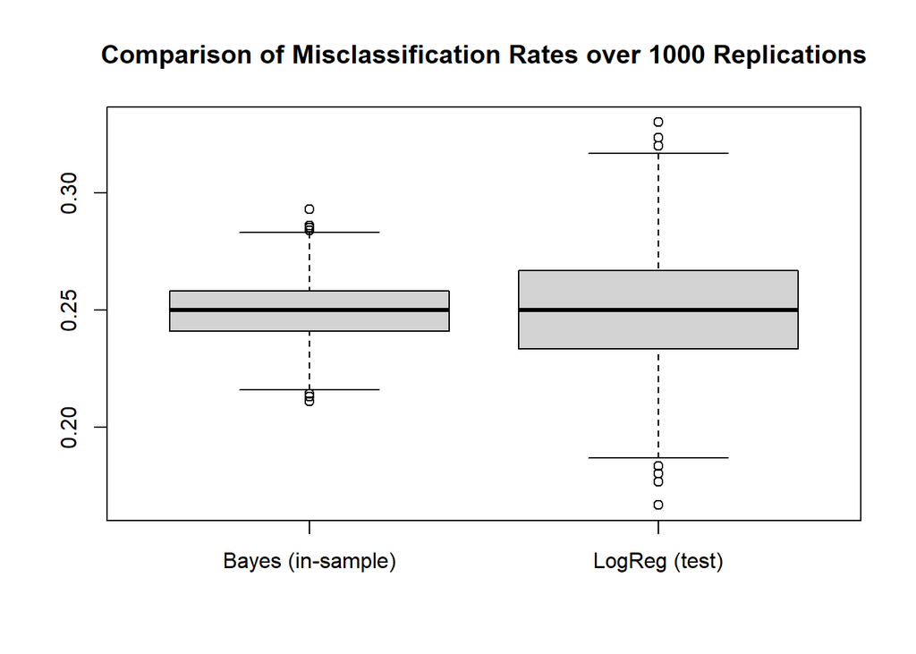

### **Interpreting the Results in Context of the Question**

The results from the Monte Carlo simulation compare the performance of the **Bayes classifier** (which represents the theoretical optimal decision rule) and **logistic regression** in terms of classification accuracy. Here’s what we can conclude:

#### **1. Comparing Misclassification Rates**

- **Bayes Classifier Misclassification Rate:** `0.249677`
- **Logistic Regression Misclassification Rate:** `0.2508633`

These values indicate that: - As expected, the **Bayes classifier** achieves a lower misclassification rate since it is based on the true conditional distributions of $X$ given $Y$. - **Logistic regression**, however, performs almost as well, with an error rate only slightly higher (by approximately `0.0012`). This suggests that logistic regression is an effective classifier in this setting, despite not having direct access to the underlying probability distributions.

======================================================== ## Warm-Up

### Pseudocode of two-sample test described by Friedman

#### 1. Create two samples, by sampling from two distributions

We are studying the test itself by selecting two distinct distributions to see how well it can differentiate between them. The null hypothesis states that the two samples come from the same distribution, while the alternative hypothesis states they come from different distributions.

SET SEED = N GENERATE DISTRIBUTION_1(parameters) GENERATE DISTRIBUTION_2(parameters) SET X = SAMPLE FROM DISTRIBUTION_1(parameters) SET y = SAMPLE FROM DISTRIBUTION_2(parameters)

#### 2. Data preparation

Next we prepare all the data to serve as training data,we proceed with labeling the data for the binary classification, such that the first (F0) distribution is labeled 0 and the second (F1) distribution is labeled 1. Once labelled, the two samples are combined into a single dataset

FOR each sample in X assign label 0 FOR each sample in Y assign label 1 SET dataset = COMBINE X and Y

#### 3. Train Binary Classifier

We select a binary classifier and train it using the whole dataset, to be capable of distinguishing between the two distributions and produce a scoring function.

TRAIN binary classifier on dataset ASSIGN scores using the classifier

#### 4. Perform the two-sample test

At this point the two sets of scores can be considered random samples, whose densities can be compared using a univariate two-sample test such as kolmogor-smirnov

COMPARE the scores using Kolmogorov-Smirnov test

#### Why are Kolmogorov-Smirnov or Mann-Whitney U tests proposed as baseline tests by Friedman?

Both of these tests are used for two-sample testing and might be used for goodness-of-fit. Although this is true only for one dimensional distributions (or as noted by Friedman with the possibility to apply them perhaps on two- or three-dimensional ones, if our sample is sufficiently large), they loose power in higher dimensions. However, if we apply the binary classifier as described by Friedman, we can reduce the problem to dimensions low enough to use the Kolmogorov-Smirnov or their counterpart to assess whether the samples proceed from the same or different distributions.

======================================================== ## Part 2: Exercise

Following Friedman’s proposal, we implement it using a binary classifier on k-variate distributions, before the application of a two-sample test. In our case, we opted for a logistic regression, in particular the glmnet() function that also applies regularization to avoid overfitting. As the two-sample test we chose the Kolmogorov-Smirnov test. The focus of this part is to study how the power of the test changes as the distance between the two distributions increases.

### Simulations

The power and size was studied under the following conditions: *the sample sizes of both distributions were set to be equal **the number of simulations was set to 50 for all cases*** the significance level was 0.05 with the exception of the simulation N.6 1. Sample Size: 50, Dimensions: 5 2. Sample Size: 100, Dimensions: 5 3. Sample Size: 50, Dimensions: 7 4. Sample Size: 50, Dimensions: 9 5. Sample Size: 50, Dimensions: 3 6. Sample Size: 50, Dimensions: 5, Alpha: 0.001

### Vizualizations

We use two plots to portray the results of each simulation, the ROC curve, and plot of the power against the distance shift between the two distributions. Thanks to ROC we obtain the Area Under the Curve (AUC), which marks the ability of the model to distinguish between two classes, such that AUC=1 would mark a model with a perfect classification ability, AUC=0.5 would suggest the models performance is of an equal quality as taking random guesses and anything below 0.5 essentially marks a performance worse than random guessing.

### Results

#### Power: The ability to correctly reject the null hypothesis

We can observe the variation in the power of the test as the distance between the two distributions increases. We can conclude that in general the power fluctuates up until the distance between the two means becomes ~0.3 or higher and then it stabilizes. As expected, with the increase in the sample size(Simulation 2) we observed a markant increase in the power of the test, where at 0.3 not only the fluctuations decreased as in other cases but at this point the type II error was compltely eliminated. When it comes to the change in dimensions, we observe the trend that with more dimensions there is improvement in the power of the test. Quite poor performance can be observed with 3 dimensional distribution (Simulation 5) as opposed to progressive improvements in simulation 1,3 and finally simulation 4.  
As we decrease the significance level the power of the method drastically reduces as well, and as we know with this also the Type I error decreases.

#### AUC: The ability to correctly distinguish the two classes

To conclude we can say that with the change in the sample size the AUC and power change in different directions, whereas with alteration in either the dimensions or the significance level the AUC and power move in the same direction.

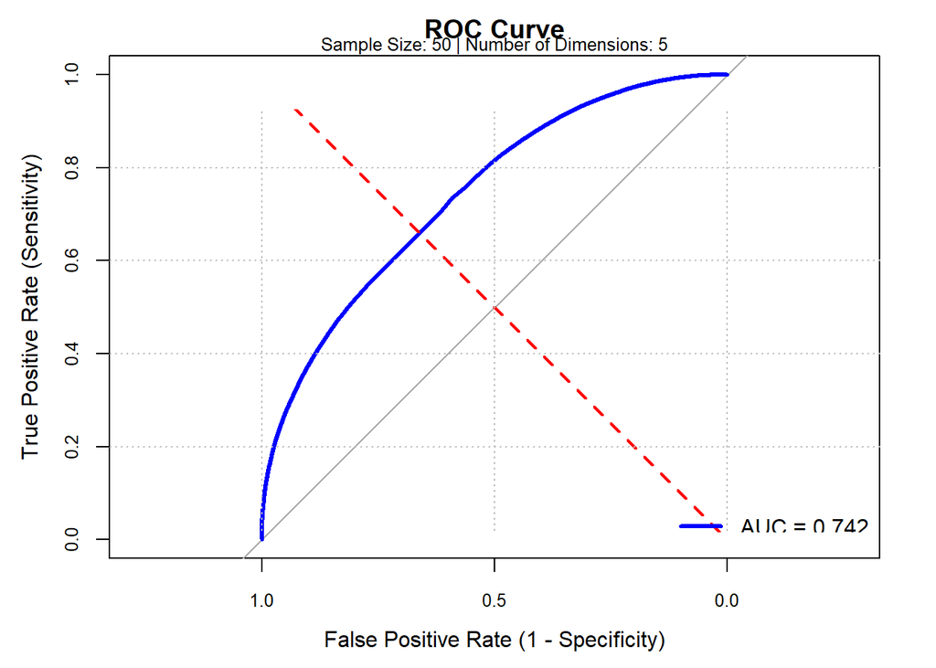

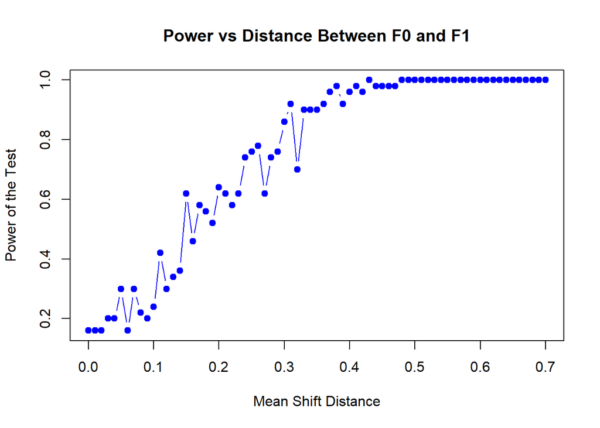

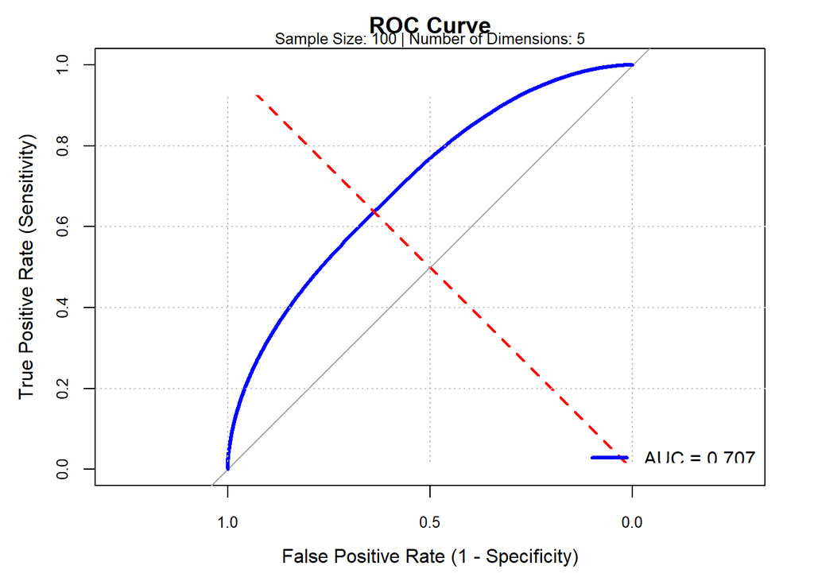

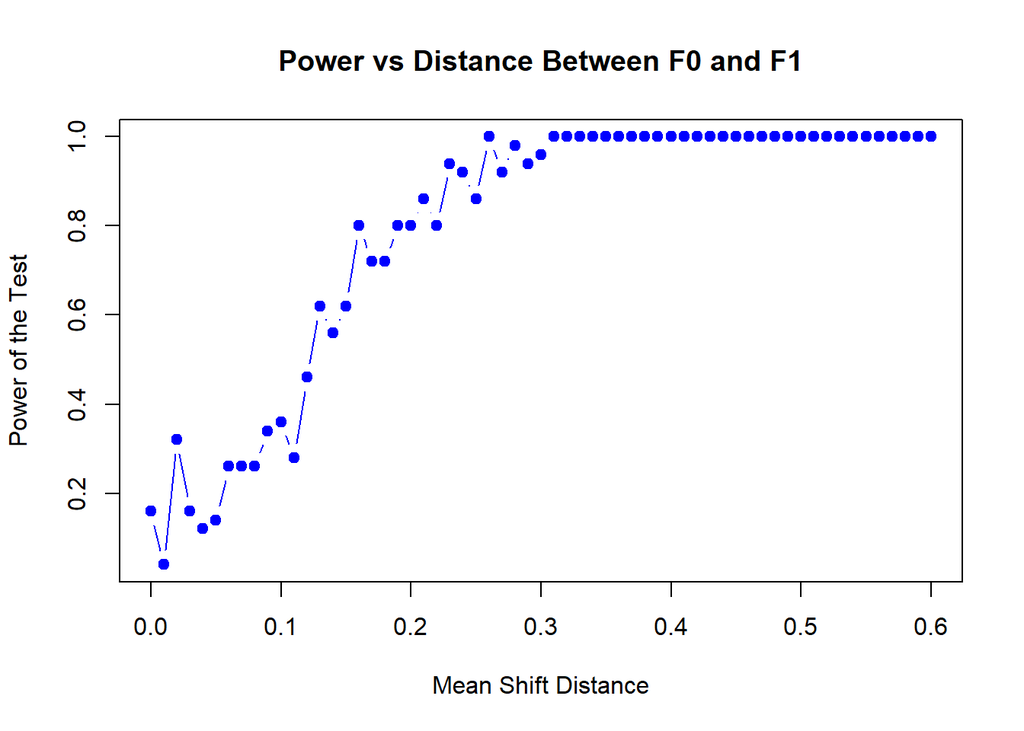

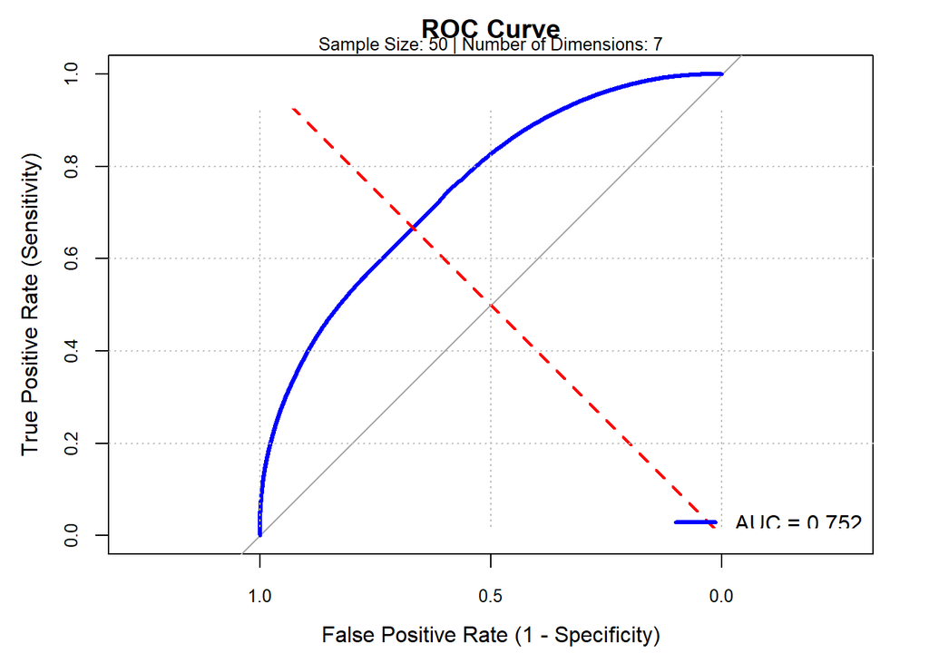

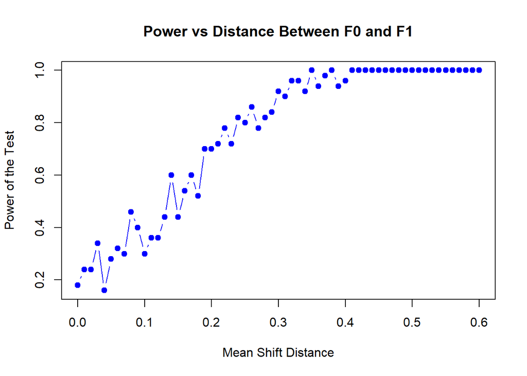

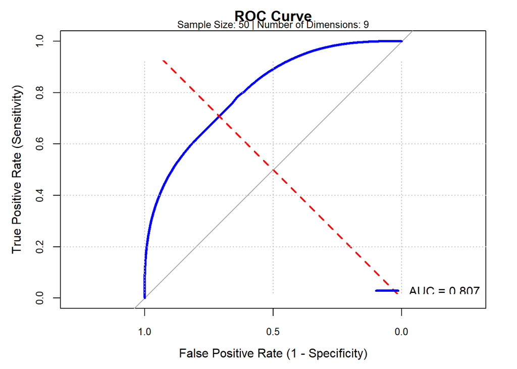

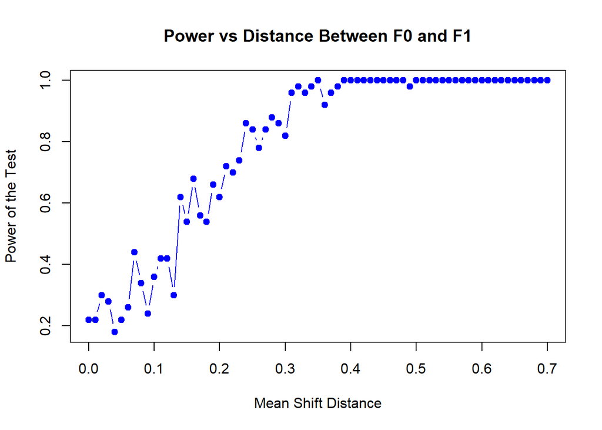

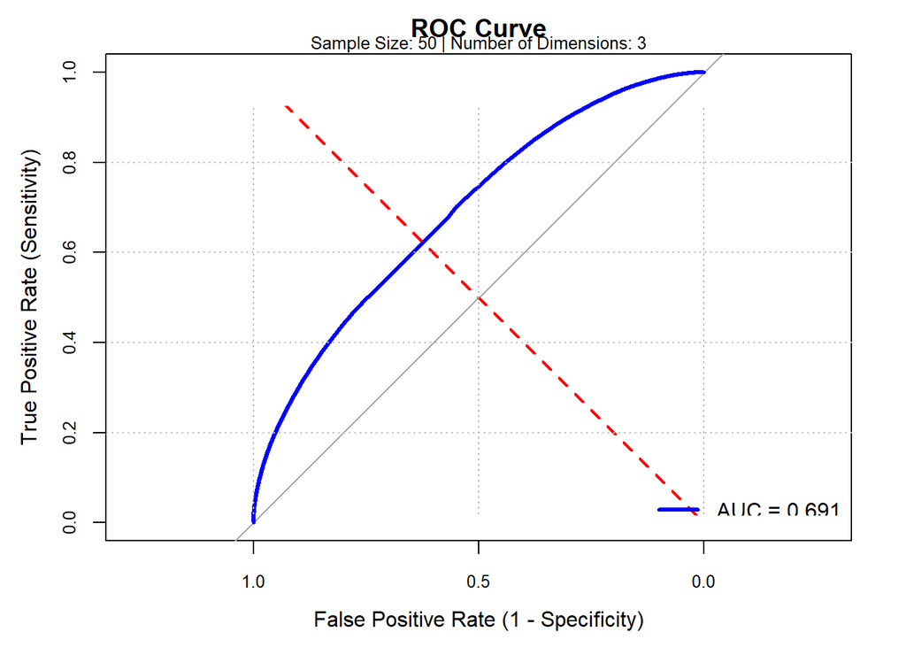

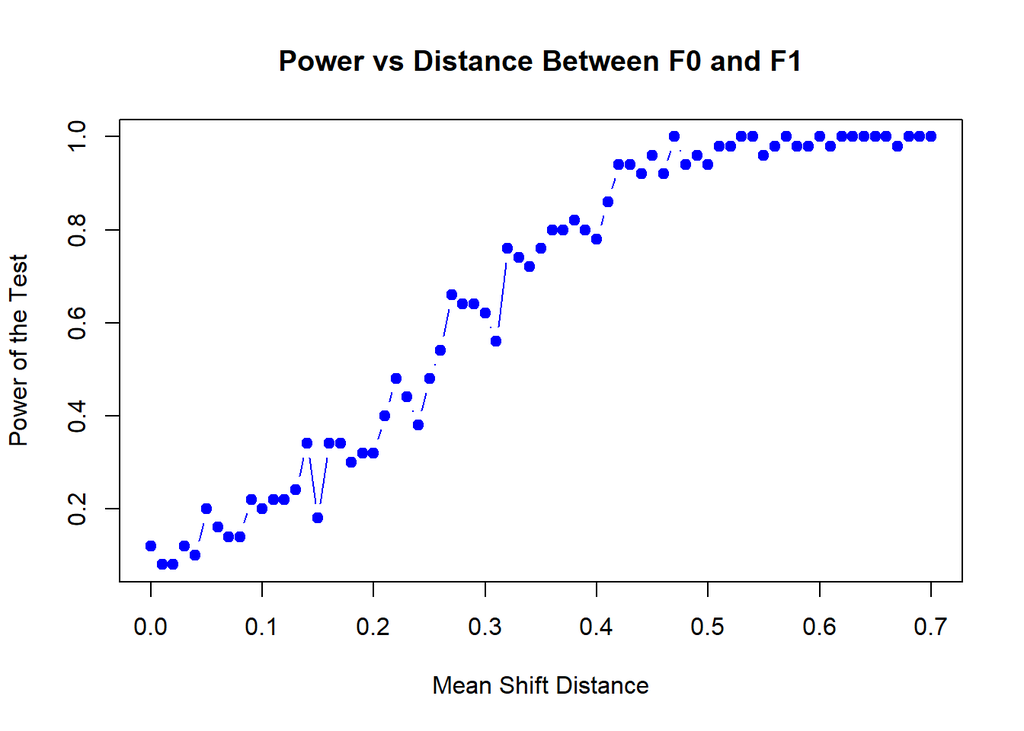

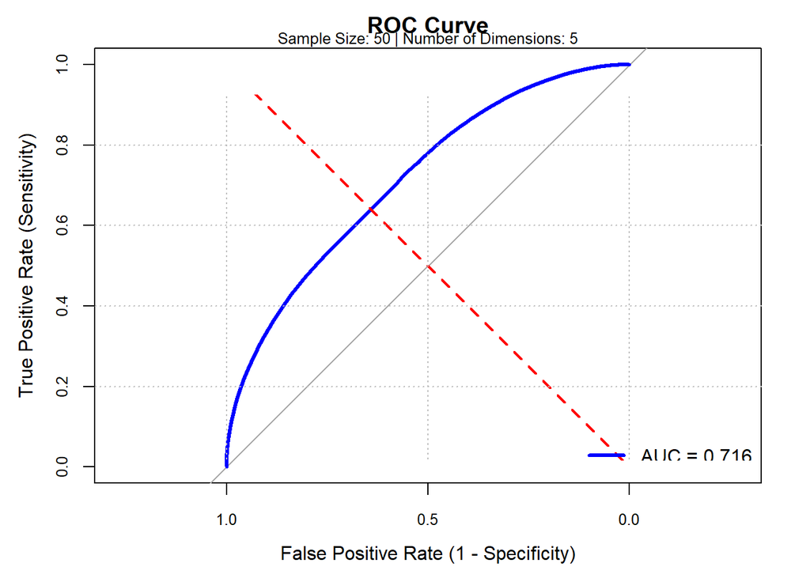

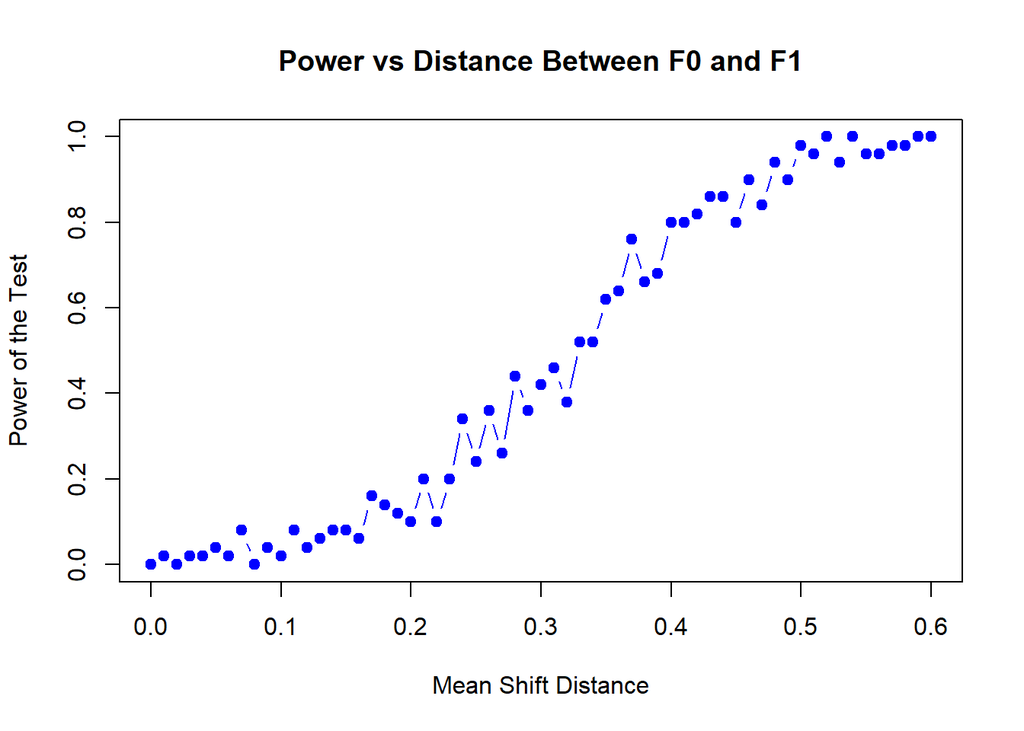

[1 more figures not shown]

========================================================

### Part 3

### The Data: Heart rate zones in running

**Heart rate zones**, or HR zones, are a way to monitor how hard you’re training. There are typically 5+1 heart rate zones (Zone-0, Zone-1, … ,Zone-5) based on the intensity of training with regard to the individual *maximum heart rate*.

HR zones are closely linked to your *aerobic* and *anaerobic* thresholds. Understanding this can really help when considering heart rate zones exercise, especially your heart rate zones for running or heart rate zone training for other fitness goals. The following HR zones chart shows the level of intensity as a percentage of Maximum Heart Rate used in each one.

| Zone | Intensity | Percentage of HRmax |
| --- | --- | --- |
| Zone 0 | Resting | - |
| Zone 1 | Very light | 50–60% |
| Zone 2 | Light | 60–70% |
| Zone 3 | Moderate | 70–80% |
| Zone 4 | Hard | 80–90% |
| Zone 5 | Maximum | 90–100% |

Modern sports watches contain many sensors to monitor *heart rate, cadence, altitude*, etc. The readings are typically saved once per second.

The present data are 60 seconds long recordings coming from **FIT files** I collected on many runs during 2021 and 2022. The runs were made in various environments, i.e., hilly and flat. Also, various efforts, e.g., long and slow runs and interval training, are included. The data collection was made using an *Apple Watch* accompanied by a **Polar OH1 sensor**.

### Step-by-Step Friedman’s Procedure

- We have two Zones (Zone-2 , Zone-3)
- We want to test if Zone-2 and Zone-3 come from the same or different distributions.
- Null Hypothesis : Both distributions are the same
- Alternative Hypothesis : The distributions are different

### Data Preprocessing

Convert the dataset into a binary classification problem:

I used −1 and 1 for classification because many machine learning models like SVM optimize better with symmetric labels around zero, improving convergence and decision boundary interpretation.

Zone-2 → Label = +1

Zone-3 → Label = -1

Since our dataset contains time-series speed & altitude data, we transform it into summary statistics:

- **Mean**
- **Standard Deviation**
- **Min**
- **Max**
- **Range**

Why This Approach?

Its simple, fast and interpretable for classification & Friedman’s Test.

**Dimensionality Reduction**: Instead of 120+ columns, we create a compact vector space.

**Preserving Important Information**: These statistics capture key trends without requiring full time-series analysis.

**Useful for Machine Learning**: This transformed dataset is better suited for classification models.

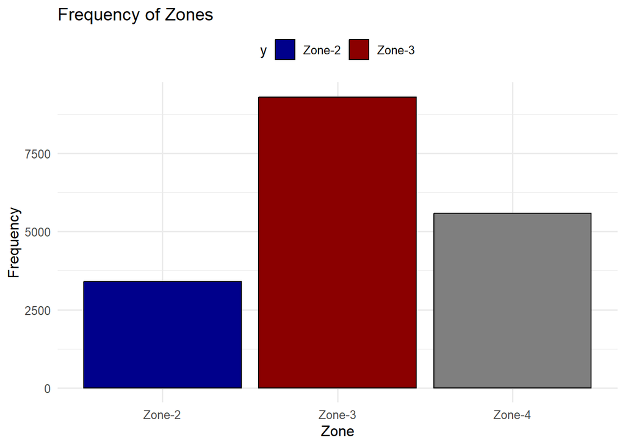

|  | Zone | speed_mean | speed_sd | speed_min | speed_max | speed_range | altitude_mean | altitude_sd | altitude_min | altitude_max | altitude_range |
| --- | --- | --- | --- | --- | --- | --- | --- | --- | --- | --- | --- |
| 17207 | -1 | 2.830883 | 0.0933496 | 2.654 | 2.996 | 0.342 | 23.90333 | 0.4737040 | 23.2 | 24.8 | 1.6 |
| 14733 | -1 | 3.516350 | 0.2250914 | 2.385 | 3.797 | 1.412 | 33.47000 | 0.4965303 | 32.6 | 34.2 | 1.6 |
| 19326 | -1 | 3.490450 | 0.1536237 | 3.251 | 3.902 | 0.651 | 22.95667 | 0.2993590 | 22.2 | 23.4 | 1.2 |
| 15719 | 1 | 2.497667 | 0.2058550 | 2.139 | 2.855 | 0.716 | 43.77333 | 1.1860584 | 41.2 | 45.2 | 4.0 |
| 19564 | 1 | 2.898233 | 0.1390175 | 2.633 | 3.139 | 0.506 | 23.64000 | 0.4275274 | 22.8 | 24.4 | 1.6 |
| 316 | -1 | 3.403467 | 0.2222682 | 2.833 | 3.713 | 0.880 | 40.72667 | 0.9907824 | 39.0 | 42.0 | 3.0 |

### Model training

We try 3 classifiers **(SVM, Random Forest and Logistic Regression)** to separate Zone-2 and Zone-3.

**SVM is our first choice** because:

1. Works well in high-dimensional feature space
2. Good for small datasets
3. Ideal for capturing non-linear relationships

All classifiers learn a function that assigns a score to each observation.

### Compute Score Values

The score values are computed as follows:

- **S⁺** → Score values assigned to Zone-2 (+1)
- **S⁻** → Score values assigned to Zone-3 (-1)

If the classifier easily separates the two groups, the two distributions are likely different.

|  | Zone | speed_mean | speed_sd | speed_min | speed_max | speed_range | altitude_mean | altitude_sd | altitude_min | altitude_max | altitude_range | Score_svm | Score_rf | Score_logistic |
| --- | --- | --- | --- | --- | --- | --- | --- | --- | --- | --- | --- | --- | --- | --- |
| 15719 | 1 | 2.497667 | 0.2058550 | 2.139 | 2.855 | 0.716 | 43.77333 | 1.1860584 | 41.2 | 45.2 | 4.0 | 0.8789613 | 0.84 | 0.7019000 |
| 17454 | -1 | 2.802200 | 0.1611140 | 2.464 | 3.089 | 0.625 | 30.13000 | 1.3573778 | 28.6 | 32.4 | 3.8 | 0.5083491 | 0.25 | 0.4980345 |
| 17399 | -1 | 3.111783 | 0.1600303 | 2.739 | 3.340 | 0.601 | 29.93667 | 0.9355442 | 28.0 | 31.0 | 3.0 | 0.1664022 | 0.05 | 0.2517510 |
| 5117 | -1 | 3.052650 | 0.2754677 | 2.413 | 3.579 | 1.166 | 36.26333 | 1.1565534 | 33.8 | 38.4 | 4.6 | 0.1338159 | 0.14 | 0.1646174 |
| 11370 | -1 | 3.177450 | 0.6885749 | 0.226 | 3.808 | 3.582 | 39.47333 | 0.6139250 | 38.4 | 40.4 | 2.0 | 0.1561964 | 0.16 | 0.1040563 |
| 18536 | -1 | 2.960583 | 0.2760167 | 2.601 | 3.703 | 1.102 | 25.36333 | 0.3974353 | 24.2 | 26.0 | 1.8 | 0.1491302 | 0.30 | 0.1291669 |

### Density plots of Score Distributions

SVM Score Distribution (Top Plot)

Strong separation:

**SVM effectively separates** Zone-2 and Zone-3.

Random Forest provides good separation but has some **misclassification**.

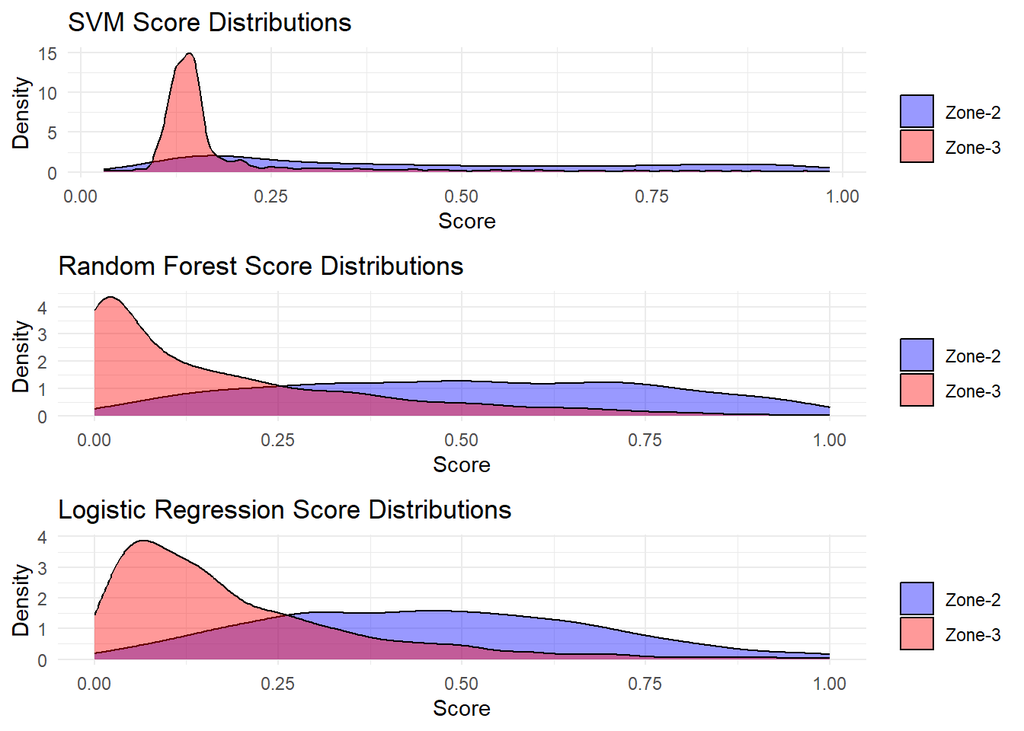

### Box plots for each classifier

[figure not shown]

### Mann-Whitney test

We Use Mann-Whitney to compare $S^+$ vs $S^-$.

Compute a test statistic $\hat{t}$:

$$\hat{t} = T(S^+, S^-)$$

where $T$ is the test function.

$H_0$: $F_(Zone2)$ = $F_(Zone3)$  
$H_1$: $F_(Zone2)$ $\neq$ $F_(Zone3)$

If p-value < 0.01, we conclude Zone-2 and Zone-3 are **significantly different**.

.

```
##
## Based on mann_whitney tests, There is a statistically significant difference between Zone-2 and Zone-3 ( 1.876198e-208  < 0.01 ). in mann_whitney_test_svm
##
## Based on mann_whitney tests, There is a statistically significant difference between Zone-2 and Zone-3 ( 1.753587e-242  < 0.01 ). in mann_whitney_test_rf
##
## Based on mann_whitney tests, There is a statistically significant difference between Zone-2 and Zone-3 ( 2.402958e-219  < 0.01 ). in mann_whitney_test_logistic
```

### Permutation test for Mann-Whitney

$H_0$: Any observed difference between $F_(Zone2)$ & $F_(Zone3)$ is due to **random label assignment**.

$H_1$: The observed difference between $F_(Zone2)$ & $F_(Zone3)$ is **statistically significant** and not due to chance.

```
##
## Based on permutation tests, There is a statistically significant difference between Zone-2 and Zone-3 ( 0  < 0.01 ). in perm_test_svm
##
## Based on permutation tests, There is a statistically significant difference between Zone-2 and Zone-3 ( 0  < 0.01 ). in perm_test_rf
##
## Based on permutation tests, There is a statistically significant difference between Zone-2 and Zone-3 ( 0  < 0.01 ). in perm_test_logistic
```

### Distribution of U-Statistics

The **blue density** curves represent the distribution of **U-statistics** under the null hypothesis (randomly permuted labels).

The distributions are **centered around lower U-statistics** values, which suggests that the test statistics obtained from the random permutations are **significantly different** from the original U-statistics.

**Original U-Statistic** (**Red Dashed Line**):

The represents the observed U-statistic from the actual Mann-Whitney test.

In all three plots, the observed U-statistic is far to the right, outside the density distribution.

**p-value**:

The in all cases is 0, meaning that none of the permuted U-statistics reached or exceeded the original U-statistic.

**This indicates strong statistical significance**

The probability of obtaining the observed U-statistic under the null hypothesis is extremely low.

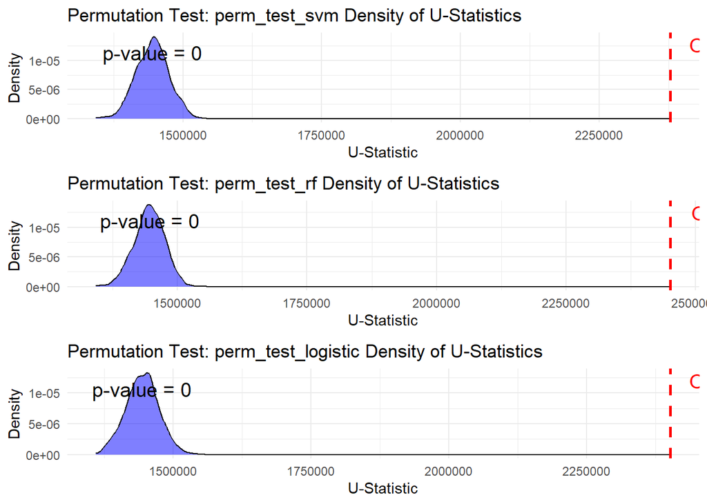

### Compute Accuracy, Confusion Matrix, and AUC

Contrasting the ROC Curve with the Score Distribution Plots Score Distributions:

**SVM** appeared to separate Zone-2 and Zone-3 best.

ROC Curve:

Random Forest is **slightly better**, but all models perform similarly overall.

This suggests that SVM was more confident in its classifications, but Random Forest might be slightly more stable across all decision thresholds.

| Model | Accuracy | AUC |
| --- | --- | --- |
| SVM | 0.7913386 | 0.8230181 |
| Random Forest | 0.7994751 | 0.8483697 |
| Logistic Regression | 0.7874016 | 0.8314339 |

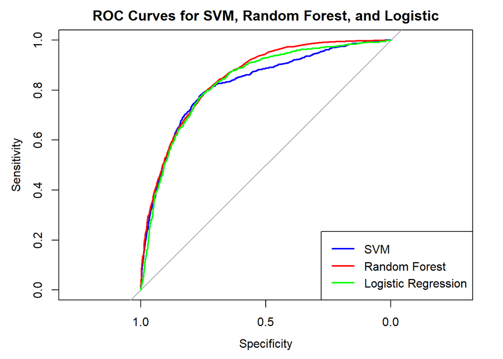

#### Classify Zone-2, Zone-3 & Zone-4

Since we now have three groups, we cannot use the Mann-Whitney U test (which is for two groups). Instead, we use **Kruskal-Wallis Test** (Non-Parametric ANOVA Equivalent)

which Tests whether three or more distributions differ. Its a generalization of the Mann-Whitney U test to multiple groups.

### Data Preprocessing

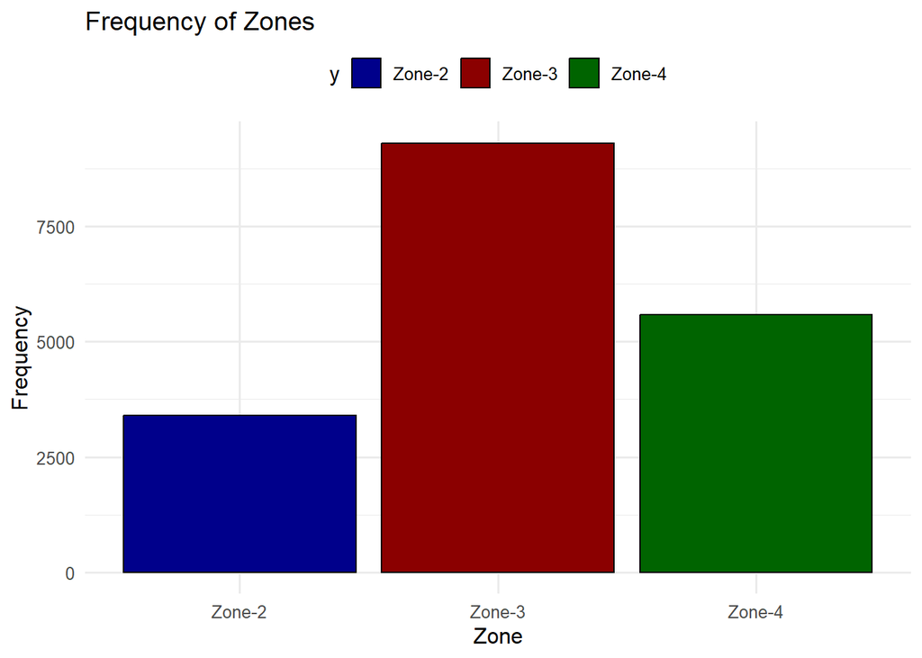

|  | Zone | speed_mean | speed_sd | speed_min | speed_max | speed_range | altitude_mean | altitude_sd | altitude_min | altitude_max | altitude_range |
| --- | --- | --- | --- | --- | --- | --- | --- | --- | --- | --- | --- |
| 17207 | -1 | 2.830883 | 0.0933496 | 2.654 | 2.996 | 0.342 | 23.90333 | 0.4737040 | 23.2 | 24.8 | 1.6 |
| 14733 | -1 | 3.516350 | 0.2250914 | 2.385 | 3.797 | 1.412 | 33.47000 | 0.4965303 | 32.6 | 34.2 | 1.6 |
| 1283 | 0 | 2.936483 | 0.8537822 | 1.484 | 4.733 | 3.249 | 31.78667 | 1.3904598 | 29.6 | 34.0 | 4.4 |
| 19326 | -1 | 3.490450 | 0.1536237 | 3.251 | 3.902 | 0.651 | 22.95667 | 0.2993590 | 22.2 | 23.4 | 1.2 |
| 3266 | 0 | 3.681683 | 0.0835146 | 3.499 | 3.845 | 0.346 | 16.05333 | 0.5714883 | 15.2 | 17.4 | 2.2 |
| 15719 | 1 | 2.497667 | 0.2058550 | 2.139 | 2.855 | 0.716 | 43.77333 | 1.1860584 | 41.2 | 45.2 | 4.0 |